# The Aharonov–Bohm Effect

When electromagnetic potentials become physically significant

Giancarmine Sparso

LMH Oxford Summer Programme 2026 · PHYS02

## How do we observe a field?

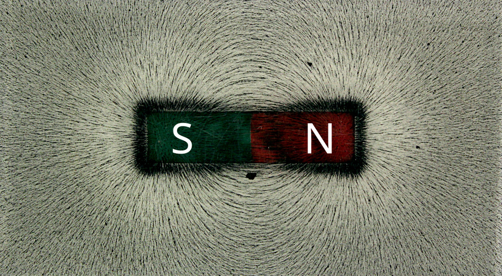

## From forces to potentials

A force is **conservative** when its effect can be encoded in a scalar function:

$$\mathbf F = - \nabla U$$

Here (U) is the **potential energy** of the probe.

But (U) depends on the probe itself. For gravity near Earth:

$$U(y)=mgy$$

So we separate the field from the probe:

$$\phi(\mathbf r)=\frac{U(\mathbf r)}{m}
\qquad \Rightarrow \qquad
\mathbf g = -\nabla \phi$$

**Potential:** field information, independent of the test body.

## Only potential differences matter

The gravitational field depends on the **slope** of the potential, not on its absolute height.

$$\mathbf g(\mathbf r)=-\nabla\Phi(\mathbf r)$$

$$\Phi'(\mathbf r)=\Phi(\mathbf r)+\boxed{C}
\quad\Longrightarrow\quad
\mathbf g'=-\nabla(\Phi+\boxed{C})=\mathbf g$$

A constant shift changes the reference level, not the physics.

[video not shown]

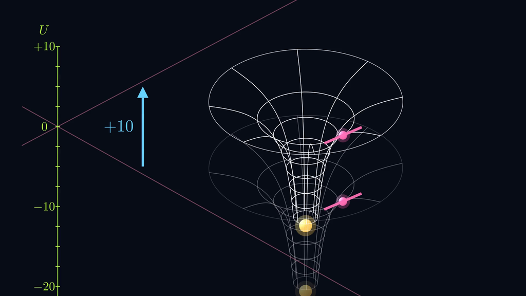

## Different potentials can produce the same field

In gravity, adding a constant to the potential does not change the physical field.

Potential shift

$$V' = V + C$$

$$\mathbf g = -\nabla V$$

Field unchanged

$$\mathbf g' = -\nabla V'$$

$$= -\nabla (V + C) = \mathbf g$$

Only differences in potential affect the field.

## Electromagnetism: more freedom, same fields

Electromagnetism needs **two potentials**: $V$, the electric scalar potential, and $\mathbf A$, the magnetic vector potential.

$$\mathbf E
=
-\nabla V
-
\frac{\partial\mathbf A}{\partial t},
\qquad
\mathbf B
=
\nabla\times\mathbf A$$

Now change the two potentials together:

$$\mathbf A'
=
\mathbf A+\nabla\chi,
\qquad
V'
=
V-\frac{\partial\chi}{\partial t}$$

$\chi(\mathbf r,t)$ may be any scalar function.

$$\mathbf E'=\mathbf E,
\qquad
\mathbf B'=\mathbf B$$

Gauge freedom is the freedom to use different potentials to describe exactly the same physical fields.

## Quantum mechanics uses the potentials directly

The wavefunction evolves according to Schrödinger’s equation:

$$i\hbar\frac{\partial \psi}{\partial t}
=
\hat H\psi$$

For a charged particle in an electromagnetic field:

$$i\hbar\frac{\partial\psi}{\partial t}
=
\left[
\frac{1}{2m}
\left(
-i\hbar\nabla
-
q\boxed{\mathbf A}
\right)^2
+
q\boxed{V}
\right]\psi$$

The equation contains the potentials $V$ and $\mathbf A$ directly.

## Aharonov’s intuition

The absolute phase of a wavefunction is not directly measurable — but phase differences are.

The uncomfortable point

In the Schrödinger equation, the particle does not couple directly to $\mathbf E$ and $\mathbf B$, but to the potentials:

$$\hat H =
\frac{1}{2m}
\left(-i\hbar\nabla - q\mathbf A\right)^2
+ qV$$

Replacing potentials with fields means differentiating:

$$\mathbf B = \nabla \times \mathbf A$$

and differentiation can erase information.

Can a quantum phase detect information that the fields have lost?

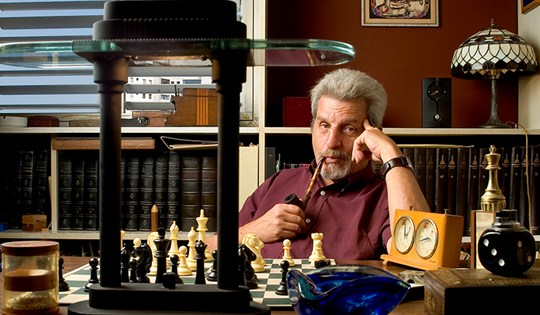

Yakir Aharonov

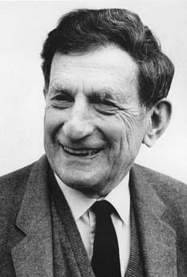

David Bohm

## The magnetic Aharonov–Bohm setup

[figure not shown]

$$\Delta\varphi
=
\frac{q}{\hbar}
\oint_C \mathbf A\cdot d\mathbf r
=
\frac{q\Phi_B}{\hbar}$$

The phase records the **enclosed magnetic flux**, not a local magnetic field.

## The Aharonov–Bohm effect in motion

[interactive chart not shown]

Φ/Φ<sub>0</sub> 0.000

## Tonomura’s toroidal experiment

[figure not shown]

**The loophole:** real solenoids leak small magnetic fields.

**Tonomura’s idea:** replace the solenoid with a **closed toroidal magnet**.

$$B = 0 \quad \text{along the electron paths}$$

$$\Delta \varphi
= \frac{q}{\hbar}\oint_C \mathbf A\cdot d\mathbf r
= \frac{q\Phi_B}{\hbar}$$

The electrons never cross the magnetic field, but the interference fringes still shift.

## Thank you for your attention

## Sources

Aharonov, Y., and D. Bohm. 1959. “Significance of Electromagnetic Potentials in the Quantum Theory.” *Physical Review* 115 (3): 485–91. https://doi.org/10.1103/PhysRev.115.485.

Aharonov, Y., and A. Casher. 1984. “Topological Quantum Effects for Neutral Particles.” *Physical Review Letters* 53 (4): 319–21. https://doi.org/10.1103/PhysRevLett.53.319.

Berry, Michael Victor. 1984. “Quantal Phase Factors Accompanying Adiabatic Changes.” *Proceedings of the Royal Society of London. A. Mathematical and Physical Sciences* 392 (1802): 45–57. https://doi.org/10.1098/rspa.1984.0023.

Chambers, R. G. 1960. “Shift of an Electron Interference Pattern by Enclosed Magnetic Flux.” *Physical Review Letters* 5 (1): 3–5. https://doi.org/10.1103/PhysRevLett.5.3.

Ehrenberg, W, and R E Siday. 1949. “The Refractive Index in Electron Optics and the Principles of Dynamics.” *Proceedings of the Physical Society. Section B* 62 (1): 8–21. https://doi.org/10.1088/0370-1301/62/1/303.

Möllenstedt, G., and W. Bayh. 1962. “Messung der kontinuierlichen Phasenschiebung von Elektronenwellen im kraftfeldfreien Raum durch das magnetische Vektorpotential einer Luftspule.” *Die Naturwissenschaften* 49 (4): 81–82. https://doi.org/10.1007/BF00622023.

Olariu, S., and I. Iovitzu Popescu. 1985. “The Quantum Effects of Electromagnetic Fluxes.” *Reviews of Modern Physics* 57 (2): 339–436. https://doi.org/10.1103/RevModPhys.57.339.

Peshkin, M., and A. Tonomura. 1989. *The Aharonov-Bohm Effect*. Lecture Notes in Physics 340. Springer. https://doi.org/10.1007/BFb0032076.

Tonomura, Akira, Nobuyuki Osakabe, Tsuyoshi Matsuda, et al. 1986. “Evidence for Aharonov-Bohm Effect with Magnetic Field Completely Shielded from Electron Wave.” *Physical Review Letters* 56 (8): 792–95. https://doi.org/10.1103/PhysRevLett.56.792.

Veritasium. 2026. *The Tiny Donut That Proved We Still Don’t Understand Magnetism*. https://www.youtube.com/watch?v=XKSjCOKDtpk.

Wu, Tai Tsun, and Chen Ning Yang. 1975. “Concept of Nonintegrable Phase Factors and Global Formulation of Gauge Fields.” *Physical Review D* 12 (12): 3845–57. https://doi.org/10.1103/PhysRevD.12.3845.